# AgriBio Stats Club + Hacky Hour

Introduction to R and pretty graphs with ggplot2

February 26th, 2020

**Objectives of today’s lesson:**

- Set the working directory
- Read data into R
- Assign values to a variable
- Plot the data using the package ggplot2

## Introduction to R

### Setting the working directory

The first thing we need to do is to set the working directory. Your working directory is the folder on your computer containing the files we will be working on. This can be done in two ways:

The first way is easy and requires no programming.

1. Click the … icon to the right under the ‘Files’ tab
2. Navigate to the folder containing the files you want to work on
3. Click the ‘More’ option and select “Set as working directory”
4. Your working directory is now set

The second way is setting the working directory programmatically. To do this, we need to know the location of the folder containing our files.

1. Right click the folder containing the files you want to work on
2. Select “Properties”
3. The “Location” is the path needed to set the working directory programmatically

The location (path) is provided as an argument to the function setwd() and replicates what we did above.

```r
setwd("E:/")
```

Once the working directory is set using either method, we can check the files contained within the folder using list.files(). The output will appear in the console.

```r
list.files()
```

If you’re somehow lost and cannot remember where your working directory is, the function getwd() will tell you where it is.

```r
getwd()
```

```
## [1] "E:/"
```

### Loading data into R

The data for this lesson is my own. This experiment was designed to test whether there is a difference between control vs. treatment and whether different genotypes respond differently to the same treatment. I measured weight, root length, and the number of lateral roots. Root length and number of lateral roots were divided to calculate lateral root density. The data is stored in a comma-separated values (CSV) format and each row holds the data for just one plant. Each column holds a different identifier - genotype, treatment, or parameter (any of weight, root length, etc). For the purposes of this exercise, it was captured at a single time point. Here’s how the the data frame looks:

```
##     Genotype Plate Treatment plant_weight root_length lateral_number
## 1 Genotype 1     1   Control          3.8          57              7
## 2 Genotype 1     1   Control          6.2          73             11
## 3 Genotype 1     1   Control          5.3          65             12
## 4 Genotype 1     1   Control          3.6          60             10
## 5 Genotype 1     1   Control          2.5          50              7
## 6 Genotype 1     1   Control          6.2          71             14
##   lateral_density
## 1           0.123
## 2           0.151
## 3           0.185
## 4           0.167
## 5           0.140
## 6           0.197
```

We’re going to load this data into R using a function called read.csv()

```r
read.csv(file = "experiment_1_raw_data.csv", header = TRUE)
```

You may have noticed that this function takes multiple arguments. We don’t need to satisfy all of them for the function to work, right now providing ‘file’ and ‘header’ will do.

When this code is executed, the output will appear in the console. This provides an opportunity to check that we loaded the right file, but the data cannot be used unless it’s assigned to a variable.

### Assigning things to a variable

I personally like to think of variables as nicknames or shortcuts to access data or values. Some liken it to a container with a name that contains data or values. New variables (nicknames) can be created and assigned values using <- or =.

Hint: the keyboard shortcut for the assignment operator (Windows) is alt + -

I often wonder how old I would be if I lived on Mercury. Mercury orbits the sun in just 88 Earth days! To calculate my age in Mercurian years, I need to calculate roughly how many days old I am and divide the result by 88.

Let’s assign our age to a variable:

```r
# this exercise assumes I'm exactly 21 years and that there are no leap years
my_age <- 21
```

The variable my_age contains the value 21. Because I stored my age in the variable my_age, I don’t need to keep typing 21. While this is currently inconvenient as the variable name is longer than the information stored within it, having it stored is important as it means that it isn’t a hard-coded value. It also reduces the risk of mis-typing my age and getting the wrong result. Understanding assigning variables is an extremely important concept in programming.

```r
# multiply the variable my_age by 365 to get age in days
my_age_days <- my_age * 365

# let's also assign the number of Earth days in a Mercurian year to a variable
mercurian_year_days <- 88
```

```r
mercurian_age <- my_age_days / mercurian_year_days

paste("My age on Mercury:", mercurian_age, "years")
```

```
## [1] "My age on Mercury: 87.1022727272727 years"
```

We can use functions inside of other functions to pretty up the result if there are too many decimal places.

```r
# using the round() function to reduce the number of decimal places
paste("My age on Mercury:", round(mercurian_age, 2), "years")
```

```
## [1] "My age on Mercury: 87.1 years"
```

Now let’s assign our data frame to a variable.

```r
df_1 <- read.csv(file = "experiment_1_raw_data.csv", header = TRUE)
```

Once the data has been loaded into R, we need to do some checking to ensure everything looks normal. The functions dim() (dimensions of your data frame) or str() (structure of your data frame) are both very useful. I prefer str() as it’s more informative. head() and tail() can also be used to look at the top and bottom of the data frame.

```r
str(df_1)
```

```
## 'data.frame':    121 obs. of  7 variables:
##  $ Genotype       : Factor w/ 2 levels "Genotype 1","Genotype 2": 1 1 1 1 1 1 1 1 1 1 ...
##  $ Plate          : int  1 1 1 1 1 1 2 2 2 2 ...
##  $ Treatment      : Factor w/ 3 levels "Control","Treatment 1",..: 1 1 1 1 1 1 1 1 1 1 ...
##  $ plant_weight   : num  3.8 6.2 5.3 3.6 2.5 6.2 2.6 4.3 4.7 7 ...
##  $ root_length    : int  57 73 65 60 50 71 50 43 64 74 ...
##  $ lateral_number : int  7 11 12 10 7 14 5 1 11 13 ...
##  $ lateral_density: num  0.123 0.151 0.185 0.167 0.14 0.197 0.1 0.023 0.172 0.176 ...
```

```r
head(df_1)
```

```
##     Genotype Plate Treatment plant_weight root_length lateral_number
## 1 Genotype 1     1   Control          3.8          57              7
## 2 Genotype 1     1   Control          6.2          73             11
## 3 Genotype 1     1   Control          5.3          65             12
## 4 Genotype 1     1   Control          3.6          60             10
## 5 Genotype 1     1   Control          2.5          50              7
## 6 Genotype 1     1   Control          6.2          71             14
##   lateral_density
## 1           0.123
## 2           0.151
## 3           0.185
## 4           0.167
## 5           0.140
## 6           0.197
```

```r
tail(df_1)
```

```
##       Genotype Plate   Treatment plant_weight root_length lateral_number
## 116 Genotype 2     3 Treatment 2         13.4          84             17
## 117 Genotype 2     3 Treatment 2         13.6          75             22
## 118 Genotype 2     3 Treatment 2         10.8          76             21
## 119 Genotype 2     3 Treatment 2         13.6          86             18
## 120 Genotype 2     3 Treatment 2         11.3          81             16
## 121 Genotype 2     3 Treatment 2         12.3          80             17
##     lateral_density
## 116           0.202
## 117           0.293
## 118           0.276
## 119           0.209
## 120           0.198
## 121           0.213
```

## Pretty graphs with ggplot2

Base R (i.e no packages) has graphing capabilites, but graphs produced using the package ggplot2 are far more customisable. Below is an example of a graph made using base R.

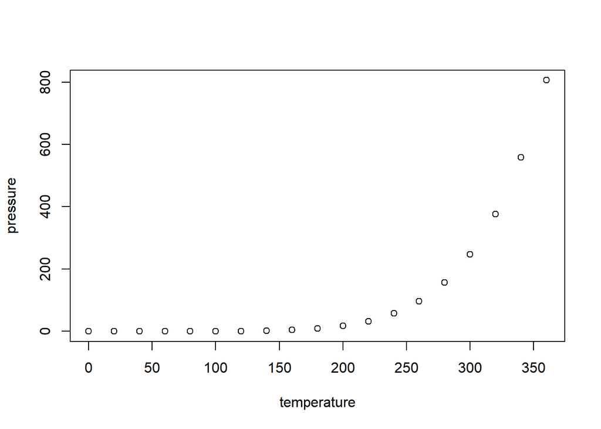

While this may be enough for some purposes, sometimes we want to make something more tailored. Let’s go ahead and install and load the package ggplot2. The function install.packages() downloads packages from repositories and installs them on the computer.

Today we’re going to use code from the resource [Data to Viz](https://www.data-to-viz.com/), more specifically the [basic boxplot with ggplot2](https://www.r-graph-gallery.com/262-basic-boxplot-with-ggplot2.html).

```r
# install the package ggplot2
# installing packages only needs to be done once
install.packages("ggplot2")
```

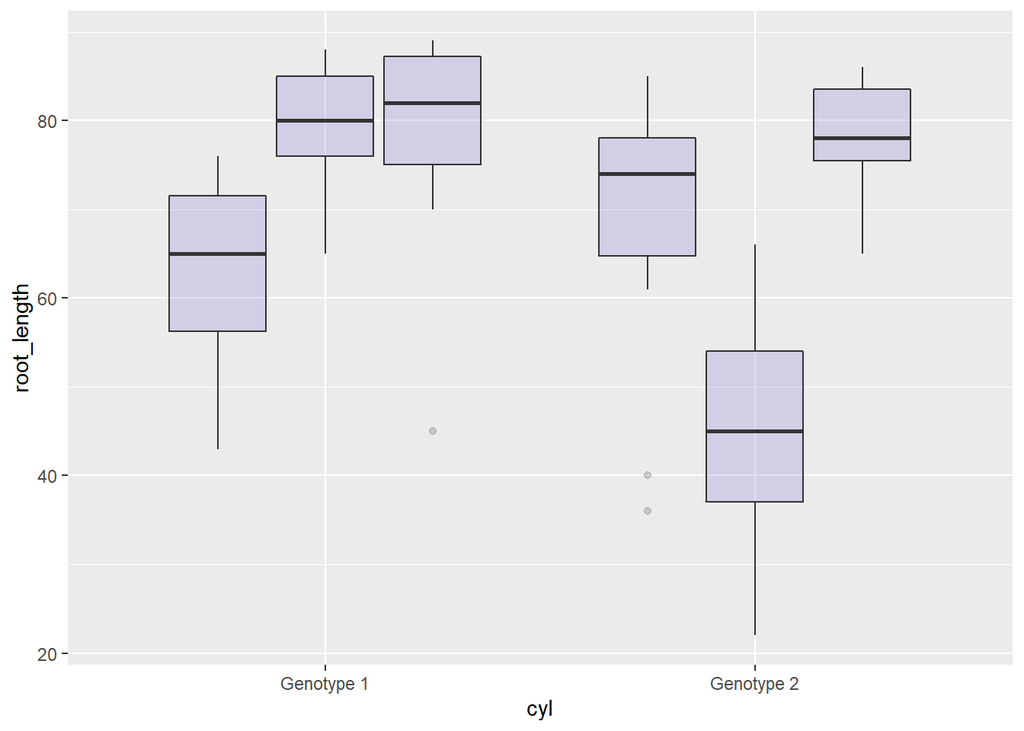

```r
# load the package so we can use its functions
# loading packages needs to be done at the start of each session
library(ggplot2)

# the code for this boxplot can be found here:
# https://www.r-graph-gallery.com/262-basic-boxplot-with-ggplot2.html
ggplot(df_1, aes(x = as.factor(Genotype),
                 y = root_length,
                 factor = Treatment)) +
    geom_boxplot(fill="slateblue", alpha=0.2) +
    xlab("cyl")
```

This graph is certainly what we’re after, but it’s not as informative as it could be. Let’s add a few extra graph elements to it.

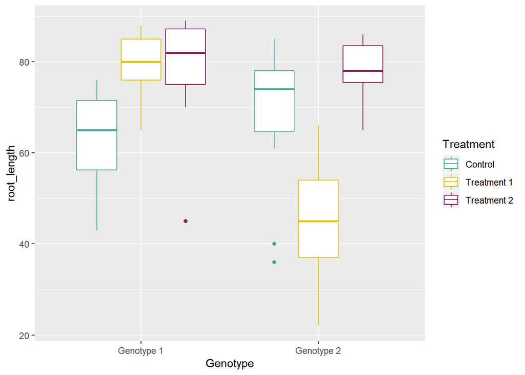

```r
ggplot(df_1, aes(x = as.factor(Genotype),
                 y = root_length,
                 factor = Treatment,
                 colour = Treatment)) +
    geom_boxplot(fill="#FFFFFF", alpha=1.0) +
    xlab("Genotype") +
    scale_colour_manual(values = c("#44aa99", "#e6c300", "#882255"),
                    labels = c("Control", "Treatment 1", "Treatment 2"))
```

You can continue to customise this graph to remove the grey grid background, put the legend position wherever you’d like, or make a prettier Y axis label.

### Resources:

Software Carpentry’s ‘Introduction to Programming with R’ course material was used as a reference for this lesson plan. See http://swcarpentry.github.io/r-novice-inflammation/.

Data visualisation options with R code to produce the selected graph https://www.data-to-viz.com/.

This document was produced in R using R Markdown.

- For more details on using R Markdown see http://rmarkdown.rstudio.com.
- If you’re really keen on pretty R Markdown documents see https://holtzy.github.io/Pimp-my-rmd/.